# Week 07 - Regression

# Linear Regression

Last week we looked at correlation, which gives us a normalized representation of how well to datasets covary, but what if we wanted to model that relationship, or even use it for prediction.

## Ordinary linear regression

OLR is a simple way to create a linear model of that relates one or more vectors (X) to a target data series (Y). Let’s use the airquality dataset to explore this.

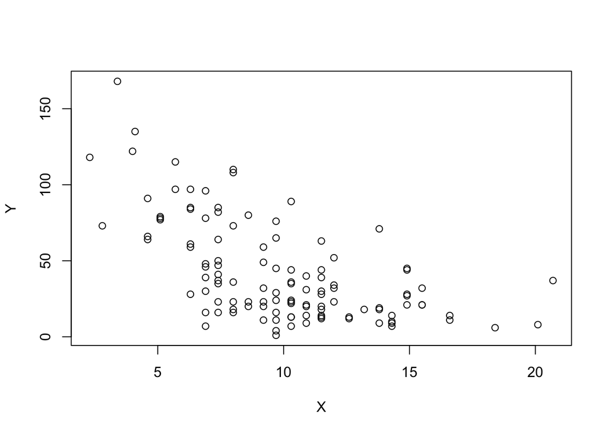

```r
X=airquality$Wind
Y=airquality$Ozone
toRemove=which(is.na(X) | is.na(Y))
X=X[-toRemove]
Y=Y[-toRemove]
plot(X,Y)
```

In regression, we will refer to X as the design matrix. This is the matrix of predictors. It must have the same number of rows as Y, but can have any number of columns. The number of columns will correspond to the number of coefficients in the model. We represent these coefficients in a column vector that has as many rows as there are columns in X.

Lets make our design matrix. It will be Wind, plus a column of ones so we can get a Y intercept in our model.

```r
ones=matrix(1,nrow=length(X))
length(X)
```

```
## [1] 116
```

```r
Xd=cbind(ones,X) #this is our design matrix
```

Linear algebra doesn’t love NAs, let’s make sure we’ve removed them all.

```r
any(is.na(Xd))
```

```
## [1] FALSE
```

Remember that in OLS, we’re trying to minimize the sum of squares of the residuals, or the error, which we call E.

$Y = Xb + E$

Where Y is a column of predictands, X is our design matrix, b is our column of coefficients, and E is the error, the difference between Xb and Y. We want to find b that makes the sum of squares in E as small as possible.

We refered to the derivation of this on the board, and will now use the result of this, called the “Normal equation” to find b, that minimize the sum of squares if E.

```r
#Use normal equation (X'X)-1 * (X'Y)
XX=t(Xd)%*%Xd
XY=t(Xd)%*%Y
B=solve(XX)%*%XY
print(B)
```

```
##        [,1]
##   96.872895
## X -5.550923
```

OK. That was easy, now we have our model. Let’s see how well it works.

Let’s use the model to calculate predicted Y over the interval 0 to 20.

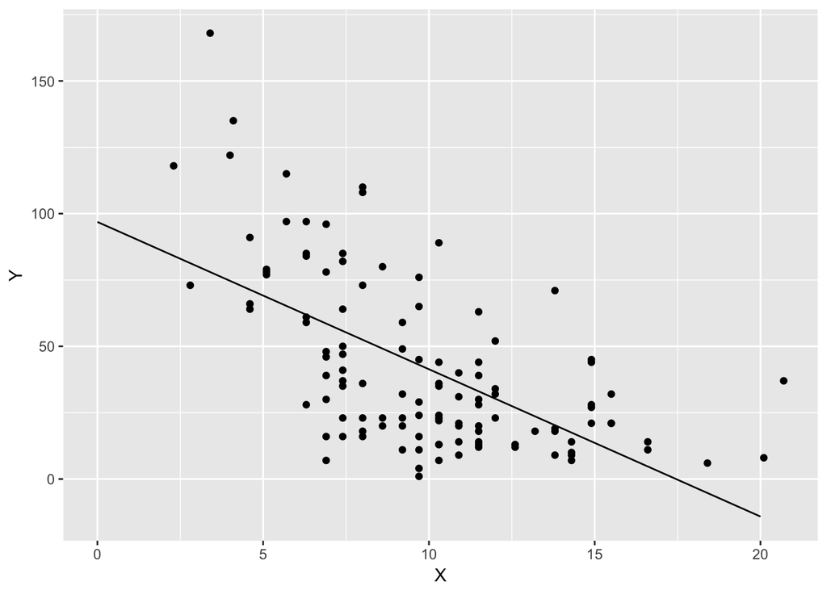

```r
xseq=seq(0,20)
yhat=xseq*B[2]+B[1] #just calculating it as a simple y=mx+b type equation.
#now lets plot the original data, and add a line for our model.
library(ggplot2)
regPlot = ggplot()+geom_point(aes(X,Y))+geom_line(aes(xseq,yhat))
print(regPlot)
```

Rather than calculating Yhat the slow way by spelling out the linear equation, we can do it simply using the design matrix, to model the values present in X. Or creating a new design matrix to model any range in X.

Remember, our equation was $Y = Xb + E$ so $\hat{Y} = Xb$

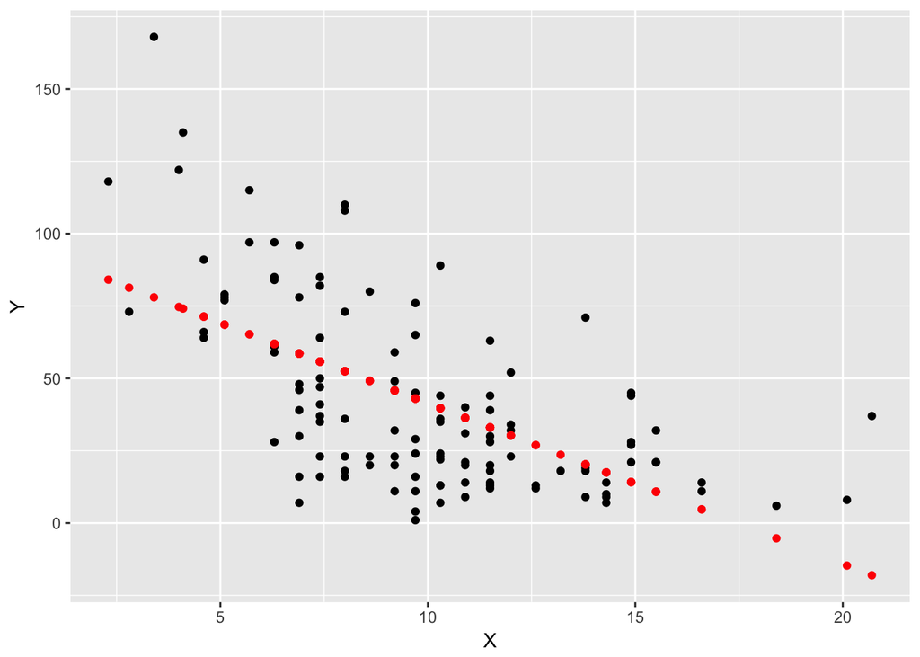

```r
yhat2 = Xd%*%B
ggplot()+geom_point(aes(X,Y))+geom_point(aes(X,yhat2),colour = "red")
```

The difference between Y and Yhat is our E. It’s also called the residuals. Let’s take a look at our residuals.

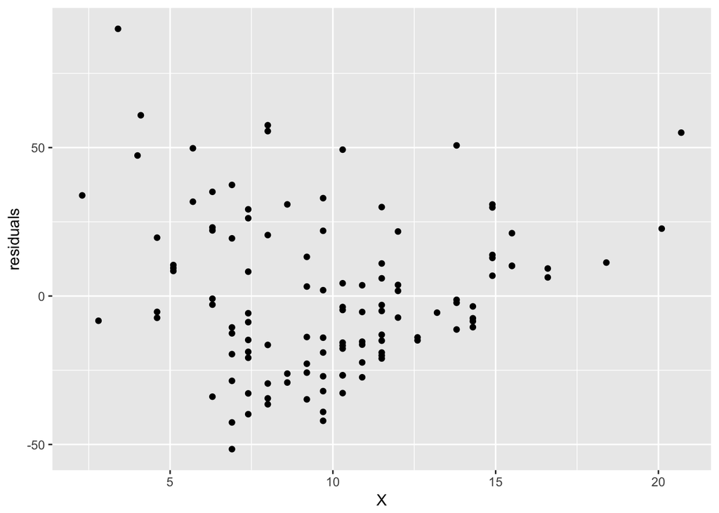

```r
residuals = Y-yhat2
ggplot()+geom_point(aes(X,residuals)) #as a line plot
```

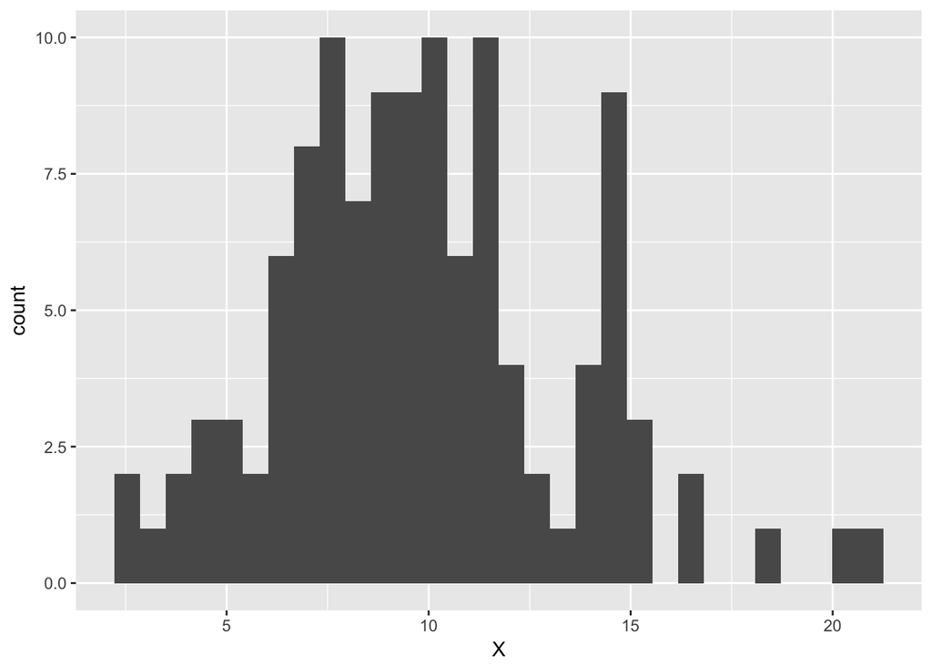

```r
ggplot()+geom_histogram(aes(X)) #as a histogram
```